# Gapminder Analysis

Julie Cardon

2024-02-07

(The above chunk determines whether or not chunks, messages, etc. will be shown– can set width and height of figures, where they’re being saved, etc.) In this document I will analyze how life expectancy has changed over time (include purpose of document) html is nice because it has continuous scroll (no page breaks, good for big docs) to put r code into document, put in chunks (title goes in curly brackets, can put in header as well) document and console can use different working directories, use knit directory to fix we used the settings button to remove output from document (see in console- you can choose) # Reading in gapminder data (header has hashtag and space before)

```r
gapminder_df <- read.csv("data/gapminder_data.csv")
```

## A smaller header

### An even smaller header

###### A very small header

Lists: make with asterisk and a space

- list item 1
- list item 2

Make hyphen lists: - Hyphen list - Hyphen list

Numbered lists: 1. Number one 2. Number two * Add 4 spaces for a sub list 3. Number 3 Put a space between header and list

We make text **bold with two asterisks** or *italics with one asterisk*

We can also insert greek letters and equations with $\mu$ or $\Delta$

We can make hyperlinks with square brackets for word we want linked, followed by parenthesis around the link like [hyperlinks](https://pad.carpentries.org/Spring2024-BIOMI6300)

# Calculating summary statistics

how many observations, and the median echo=FALSE within the chunk title won’t show the code in the document

Over 1704 observations, the median population was 7.024 million people. notice in-line r codes, and how that shows up in the knitted text.

#Plotting life Expectancy Over the Years

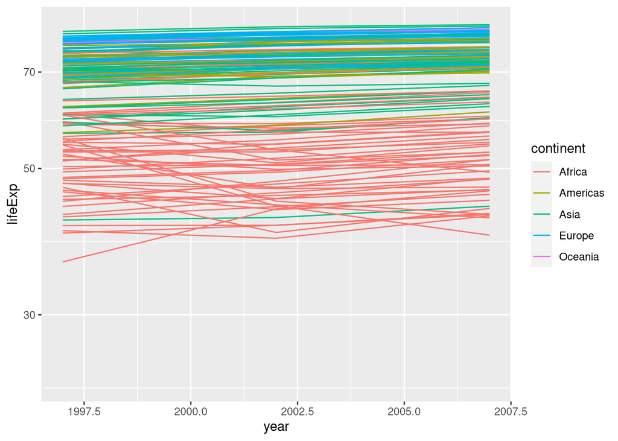

```r
library(ggplot2) #(the hashtag makes it so r doesn't read the code)
ggplot(gapminder_df, aes(x = year, y = lifeExp, group = country, color = continent)) + geom_line() + scale_y_log10() + scale_x_continuous(limits = c(1997, 2007))
```

warnings can be silenced in title of code chunk # Make a line plot # log scale y axis # Bonus: Change the theme

always have the library loading step in your r chunk eval = false (shows code, but doesn’t run it, output = false, run code but not show)

#Plotting Population Distribution

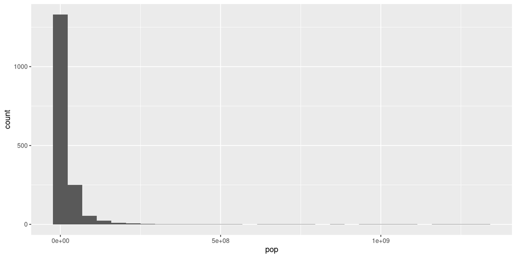

```r
ggplot(gapminder_df, aes(x=pop)) + geom_histogram()
```

message in r- nothing went wrong, but you should know… (message is not useful to reader, so you can put in message = false so it doesn’t print the message)

YAML is the program that makes the header (can add options to html)